# Ch5 Visualization Case Study

Let’s remake the plot, but only for this subset by simply adding `country %in% country_list` to the `filter` function:

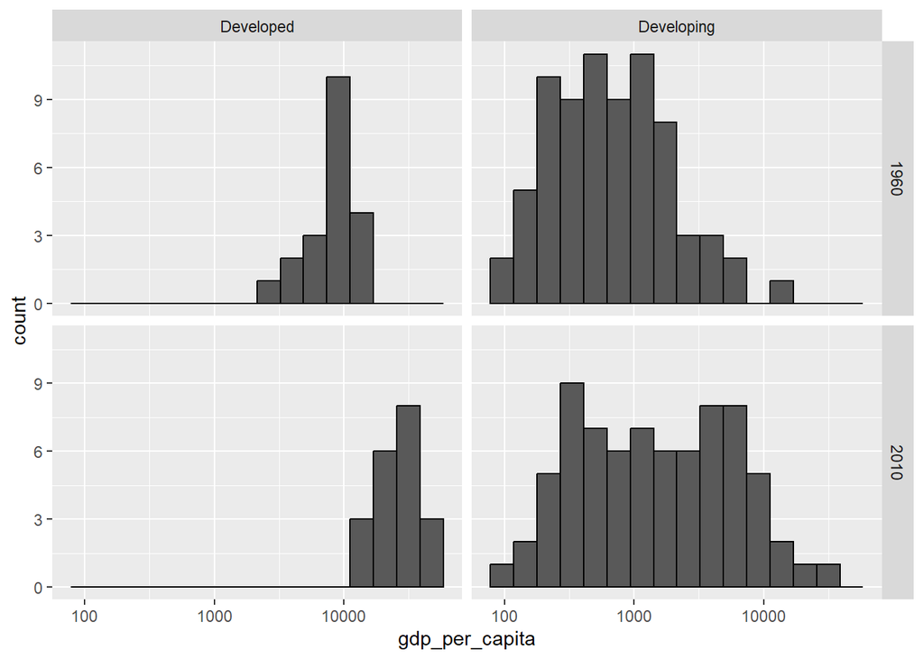

```r
gapminder %>%
  filter(year %in% years & country %in% country_list) %>%
  mutate(west = ifelse(group == "Developed", "Developed", "Developing")) %>%
  ggplot(aes(gdp_per_capita)) +
  geom_histogram(binwidth = 0.18, color = "black") +
  scale_x_continuous(trans = "log10") +
  facet_grid(year ~ west)
```

To see which specific regions improved the most, we can remake the boxplots we made above, but now adding the year 2010 and then using facet to compare the two years.

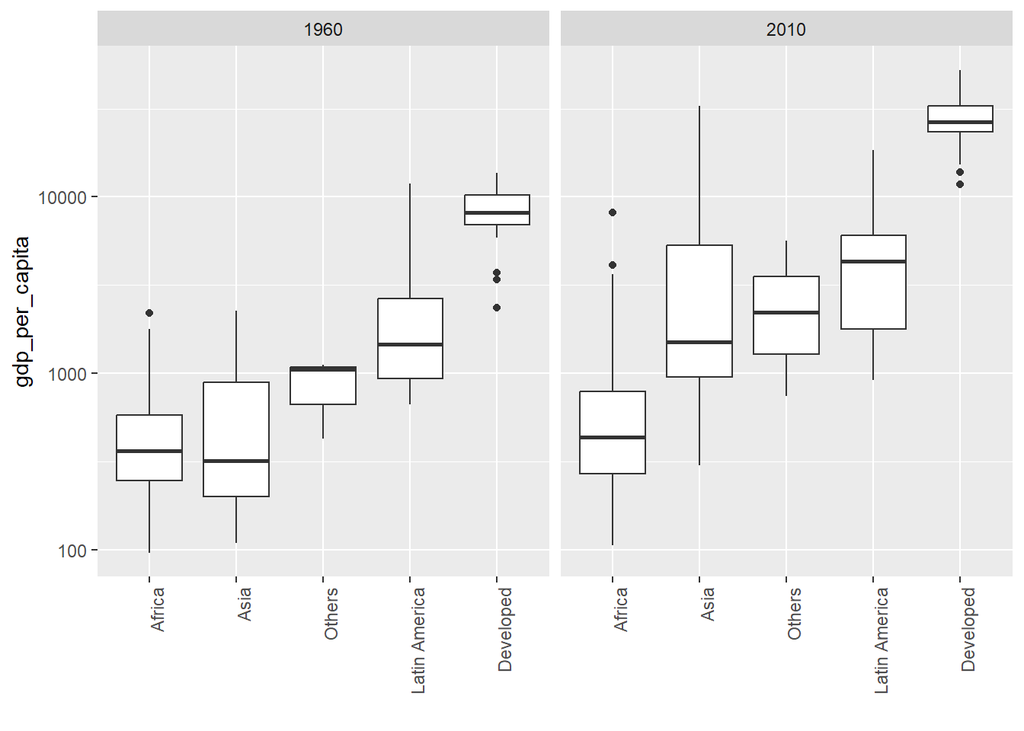

```r
gapminder %>%
  filter(year %in% years & country %in% country_list) %>%
  ggplot(aes(reorder(group, gdp_per_capita, median), gdp_per_capita)) +
  geom_boxplot() +
  theme(axis.text.x = element_text(angle = 90, hjust = 1)) +
  scale_y_continuous(trans = "log10") +
  xlab("") +
  facet_grid( ~ year)
```

Here, we pause to introduce another powerful **ggplot2** feature. Because we want to compare each region before and after, it would be convenient to have the 1960 boxplot next to the 2010 boxplot for each region. In general, comparisons are easier when data are plotted next to each other.

So instead of faceting, we keep the data from each year together and ask to color (or fill) them depending on the year. Note that groups are automatically separated by year and each pair of boxplots drawn next to each other. Because year is a number, we turn it into a factor since **ggplot2** automatically assigns a color to each category of a factor. Note that we have to convert the year columns from numeric to factor.

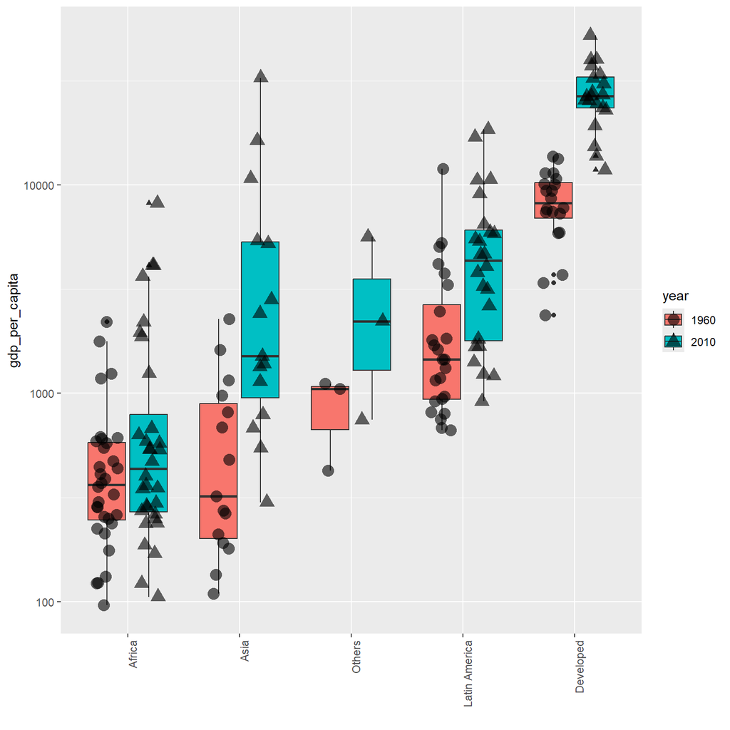

```r
gapminder %>%
  filter(year %in% years & country %in% country_list) %>%
  mutate(year = factor(year)) %>%
  ggplot(aes(reorder(group, gdp_per_capita, median),
             gdp_per_capita,
             shape = year,
             fill = year)) +
  geom_boxplot() +
  geom_point(
    position = position_jitterdodge(),#jitter.width = 0.15,dodge.width = 0.7
    alpha = 0.6,size = 4) +
  scale_y_continuous(trans = "log10") +
  xlab("") +
  theme(axis.text.x = element_text(angle = 90, hjust = 1))
```

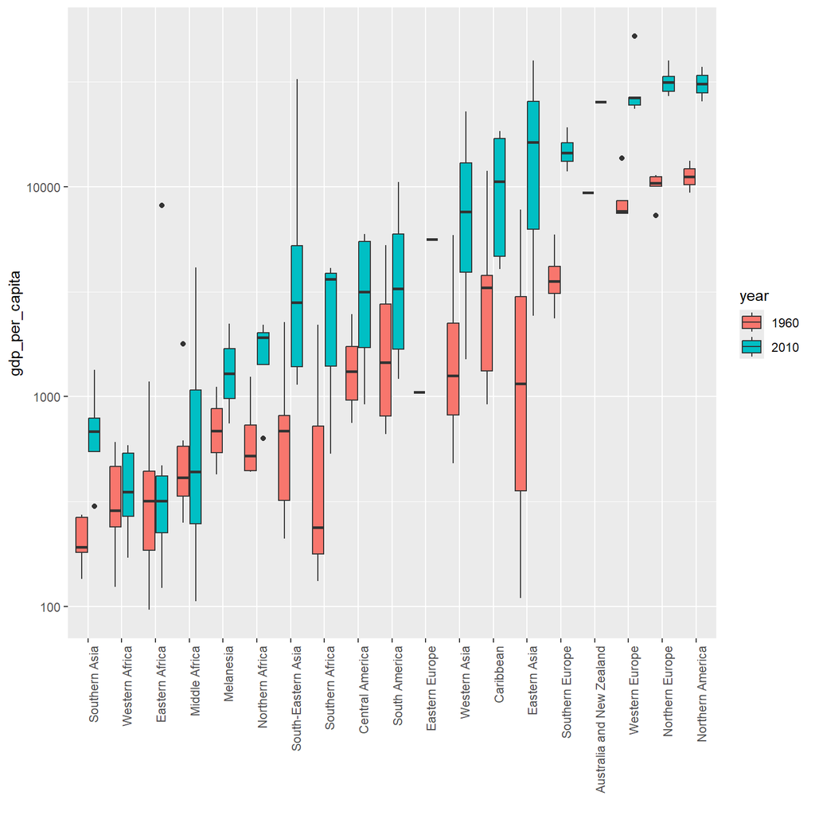

```r
gapminder %>%
  filter(year %in% years & country %in% country_list) %>%
  mutate(year = factor(year)) %>%
  ggplot(aes(reorder(region, gdp_per_capita, median), gdp_per_capita, fill = year)) +
  geom_boxplot() +
  scale_y_continuous(trans = "log10") +
  xlab("") +
  theme(axis.text.x = element_text(angle = 90, hjust = 1))
```

Finally, we point out that if what we are most interested in is comparing before and after values, it might make more sense to plot the percentage increases.

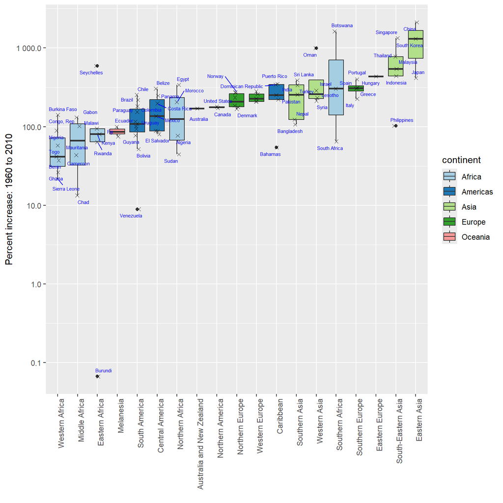

```r
gapminder %>%
  filter(year %in% years & country %in% country_list) %>%
  mutate(year = ifelse(year == past_year, "past", "present")) %>%
  select(country, region, year, gdp_per_capita, continent) %>%
  pivot_wider(names_from = year, values_from= gdp_per_capita) %>%
  mutate(percent_increase = (present-past)/past*100) %>%
  #mutate(region = reorder(region,percent_increase, FUN = median)) %>%
  ggplot(aes(reorder(region,percent_increase, FUN = median), percent_increase, fill = continent)) +
    geom_boxplot() +
    geom_jitter(width=0.1,shape=4, show.legend = FALSE) +
    geom_text_repel(aes(label = country), size=2, color="blue") +
    scale_y_continuous(trans = "log10",
                       labels = label_number()) +
    scale_fill_brewer(palette = "Paired") +
    theme(axis.text.x = element_text(angle = 90, hjust = 1)) +
    xlab("") +
    ylab(paste("Percent increase:", past_year, "to", present_year))
```

**Summary**

Let’s start by noting that density plots for income distribution in 1960 and 2010 deliver the message that the gap is closing:

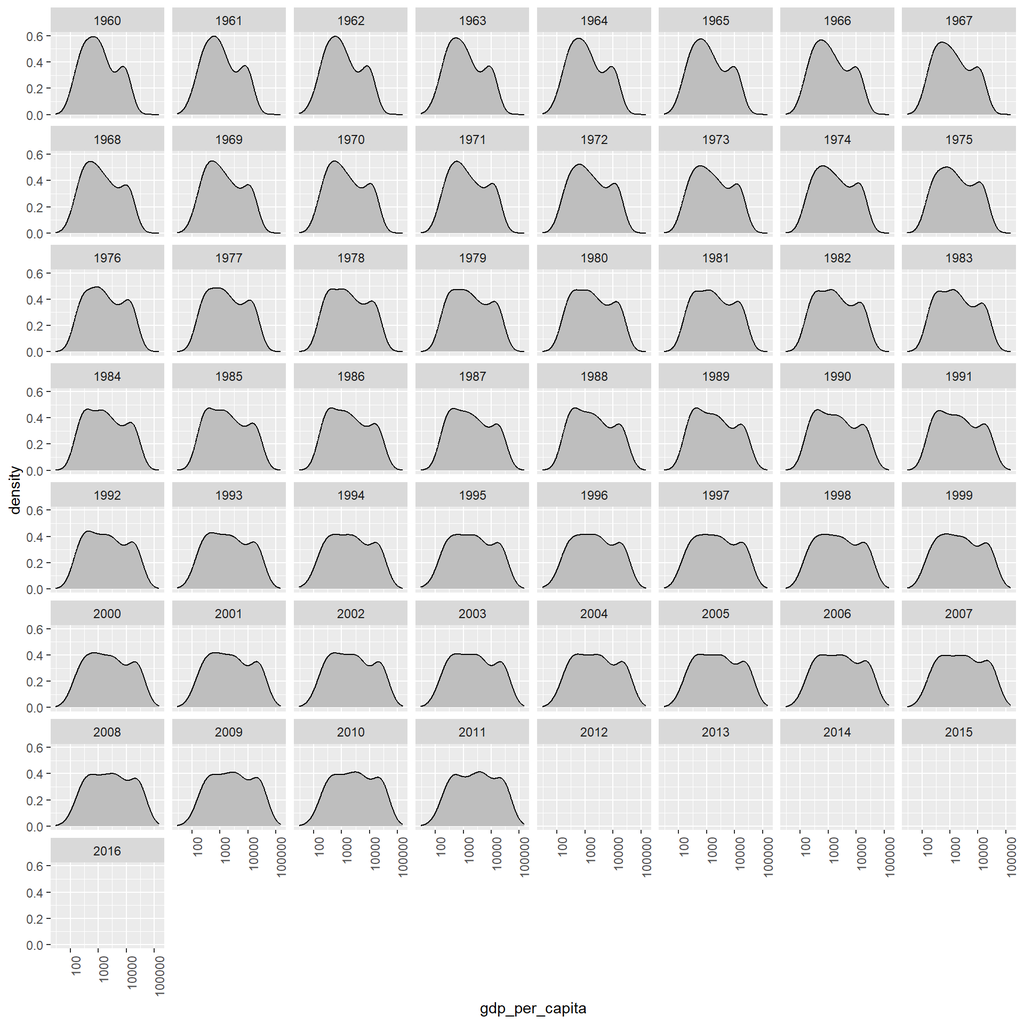

```r
gapminder %>%
  filter(country %in% country_list) %>%
  ggplot(aes(gdp_per_capita)) +
    geom_density(fill = "grey") +
    scale_x_continuous(trans = "log10", limit = c(30, 150000),
                       breaks=c(100,1000,10000,100000),
                       labels=c("100","1000","10000","100000")) +
    theme(axis.text.x = element_text(angle = 90, hjust = 1)) +
    facet_wrap(~ year)
```

In the 1960 plot, we see two clear modes: poor and rich countries. In 2010, it appears that some of the poor countries have shifted towards the right, closing the gap.

The next message we need to convey is that the reason for this change in distribution is that several poor countries became richer, rather than some rich countries becoming poorer. To do this, we can assign a color to the groups we identified during data exploration.

However, we first need to learn how to make these smooth densities in a way that preserves information on the number of countries in each group. To understand why we need this, note the discrepancy in the size of each group:

| Developed | Developing |
| --- | --- |
| 20 | 74 |

But when we overlay two densities, the default is to have the area represented by each distribution add up to 1, regardless of the size of each group. This makes it appear as if there are the same number of countries in each group. To change this, we will need to learn to access computed variables with `geom_density` function.

To have the areas of these densities be proportional to the size of the groups, we can simply multiply the y-axis values by the size of the group. From the `geom_density` help file, we see that the functions compute a variable called `count` that does exactly this. We want this variable to be on the y-axis rather than the density.

In **ggplot2**, we access these variables by surrounding the name with two dots. We will therefore use the following mapping. If we want the densities to be smoother, we use the `bw` argument so that the same bandwidth is used in each density. We selected 0.2 after trying out several values.

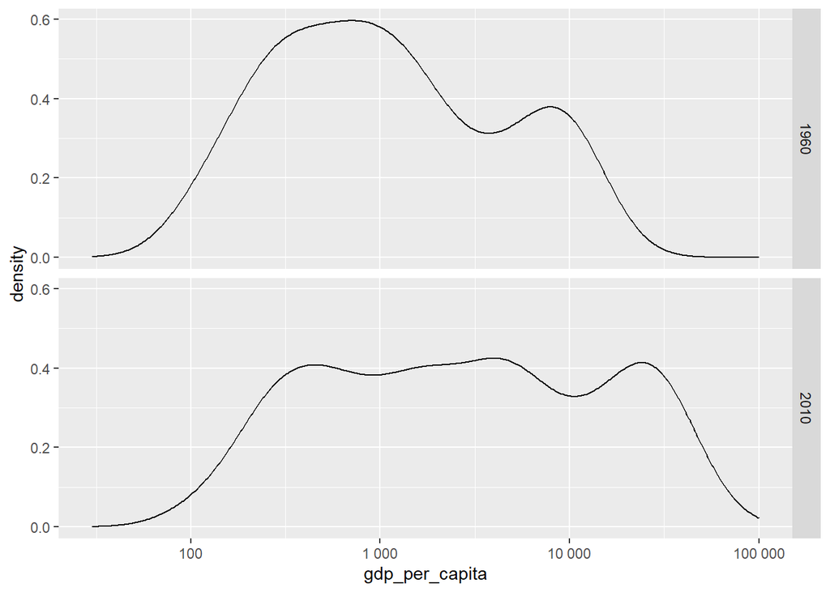

```r
gapminder %>%
  filter(year %in% years & country %in% country_list) %>%
  ggplot(aes(x = gdp_per_capita)) +
    scale_x_continuous(trans = "log10", limit = c(30,100000),
                       labels = label_number()) +
    geom_density(alpha = 0.2, bw = 0.2) +
    facet_grid(year ~ .)
```

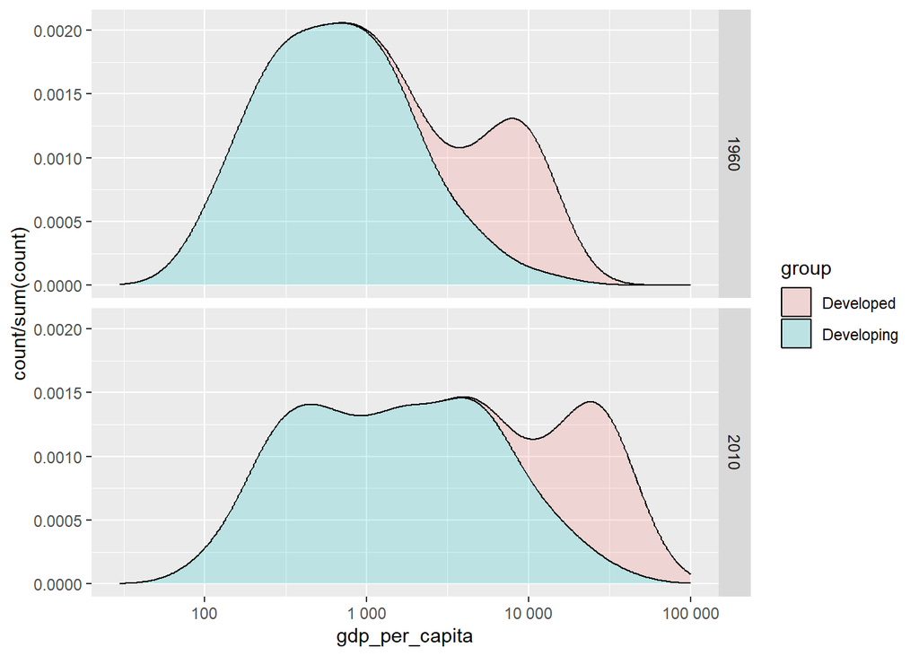

```r
gapminder %>%
  filter(year %in% years & country %in% country_list) %>%
  mutate(group = ifelse(group == "Developed", "Developed", "Developing")) %>%
  ggplot(aes(x = gdp_per_capita, y = ..count../sum(..count..), fill = group)) +
    scale_x_continuous(trans = "log10", limit = c(30,100000),
                       labels = label_number()) +
    geom_density(alpha = 0.2, bw = 0.2, position = "stack") +
    facet_grid(year ~ .)
```

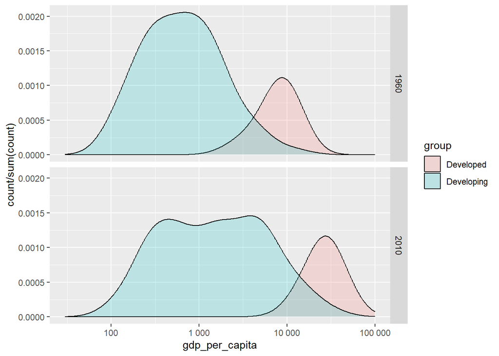

```r
gapminder %>%
  filter(year %in% years & country %in% country_list) %>%
  mutate(group = ifelse(group == "Developed", "Developed", "Developing")) %>%
  ggplot(aes(x = gdp_per_capita, y = ..count../sum(..count..), fill = group)) +
    scale_x_continuous(trans = "log10", limit = c(30,100000),
                       labels = label_number()) +
    geom_density(alpha = 0.2, bw = 0.2) +
    facet_grid(year ~ .)
```

This plot now shows what is happening very clearly. The developing world distribution is changing. A third mode appears consisting of the countries that most narrowed the gap.

To visualize if any of the groups defined above are driving this we can quickly make a ridge plot:

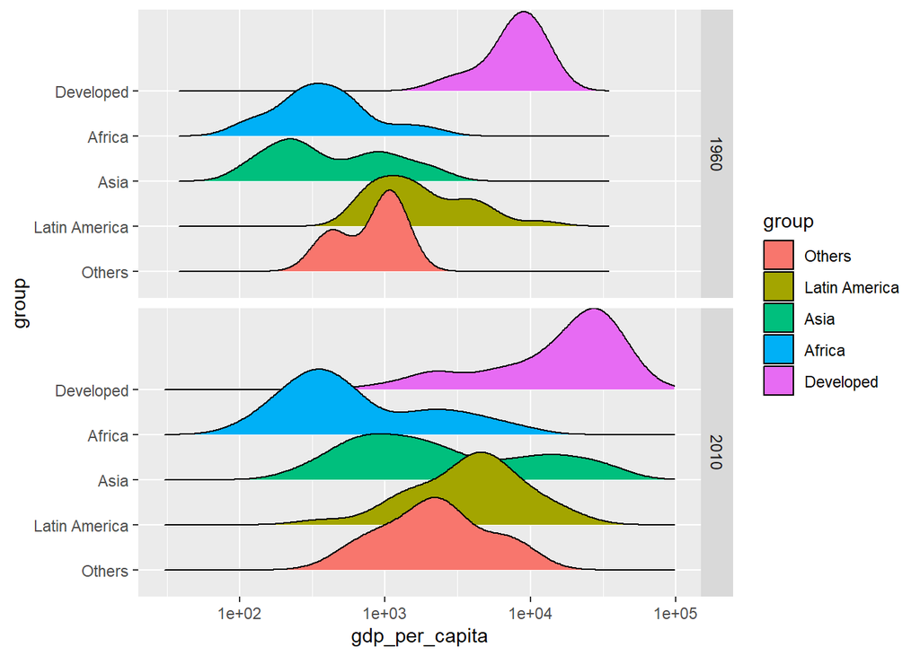

```r
gapminder %>%
  filter(year %in% years & !is.na(gdp_per_capita)) %>%
  ggplot(aes(gdp_per_capita, group, fill = group)) +
    geom_density_ridges(adjust = 1.5) +
    scale_x_continuous(trans = "log10", limit = c(30,100000)) +
    facet_grid(year ~ .)
```

Here we can clearly see how the distributions for East Asia, Latin America, and others shift markedly to the right. While Sub-Saharan Africa remains stagnant.

Notice that we order the levels of the group so that the West’s density is plotted first, then Sub-Saharan Africa. Having the two extremes plotted first allows us to see the remaining bimodality better.

**Weighted vs Unweighted Analysis:**

As a final point, we note that these distributions weigh every country the same. So if most of the population is improving, but living in a very large country, such as China, we might not appreciate this. We can actually weight the smooth densities using the `weight` mapping argument. The plot then looks like this:

This particular figure shows very clearly how the income distribution gap is closing with most of the poor remaining in Sub-Saharan Africa.

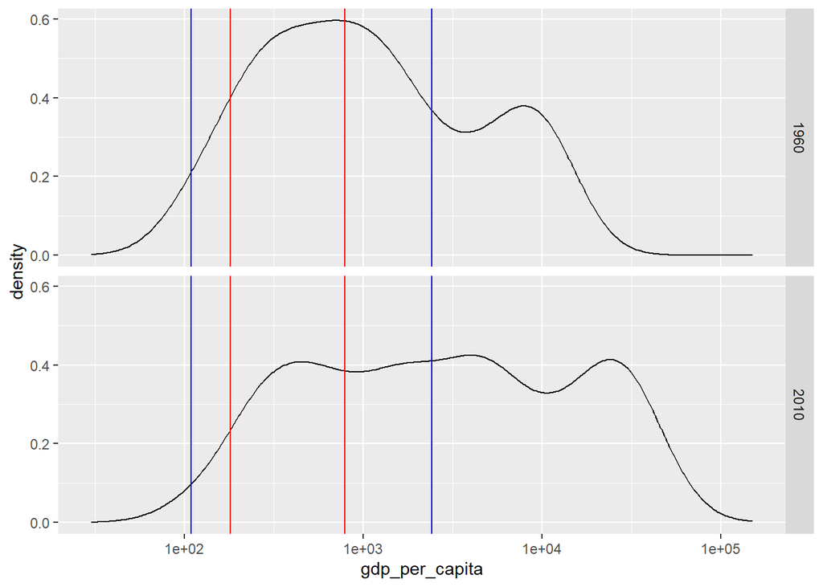

```r
gapminder %>%
  mutate(gdp_per_capita = gdp/population) %>%
  filter(year %in% years & country %in% country_list) %>%
  group_by(year) %>%
  mutate(weight = population/sum(population)) %>%
  ungroup() %>%
  ggplot(aes(gdp_per_capita)) +
  geom_density(bw = 0.2, position = "stack") +
  scale_x_continuous(trans = "log10", limit = c(30, 150000)) +
  facet_grid(year ~ .) +
  geom_vline(xintercept = gapminder %>%
               filter(country == "China",
                      year %in% c(1960,2010)) %>%
               select(gdp_per_capita) %>%
               unlist(),
             color = "blue") +
  geom_vline(xintercept = gapminder %>%
               filter(country == "India",
                      year %in% c(1960,2010)) %>%
               select(gdp_per_capita) %>%
               unlist(),
             color = "red")
```

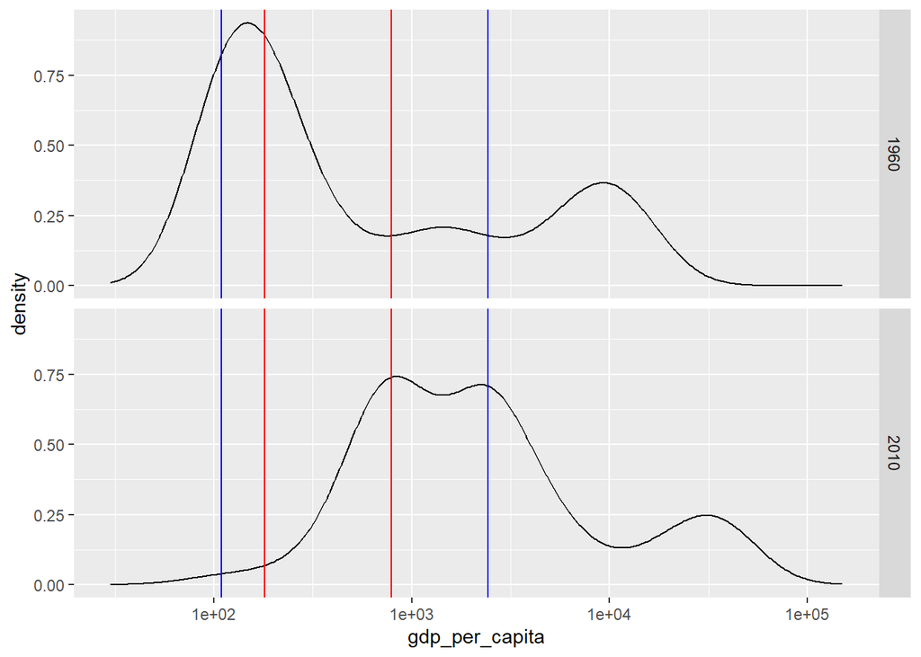

```r
gapminder %>%
  mutate(gdp_per_capita = gdp/population) %>%
  filter(year %in% years & country %in% country_list) %>%
  group_by(year) %>%
  mutate(weight = population/sum(population)) %>%
  ungroup() %>%
  ggplot(aes(gdp_per_capita, weight = weight)) +
  geom_density(bw = 0.2, position = "stack") +
  scale_x_continuous(trans = "log10", limit = c(30, 150000)) +
  facet_grid(year ~ .) +
  geom_vline(xintercept = gapminder %>%
               filter(country == "China",
                      year %in% c(1960,2010)) %>%
               select(gdp_per_capita) %>%
               unlist(),
             color = "blue") +
  geom_vline(xintercept = gapminder %>%
               filter(country == "India",
                      year %in% c(1960,2010)) %>%
               select(gdp_per_capita) %>%
               unlist(),
             color = "red")
```

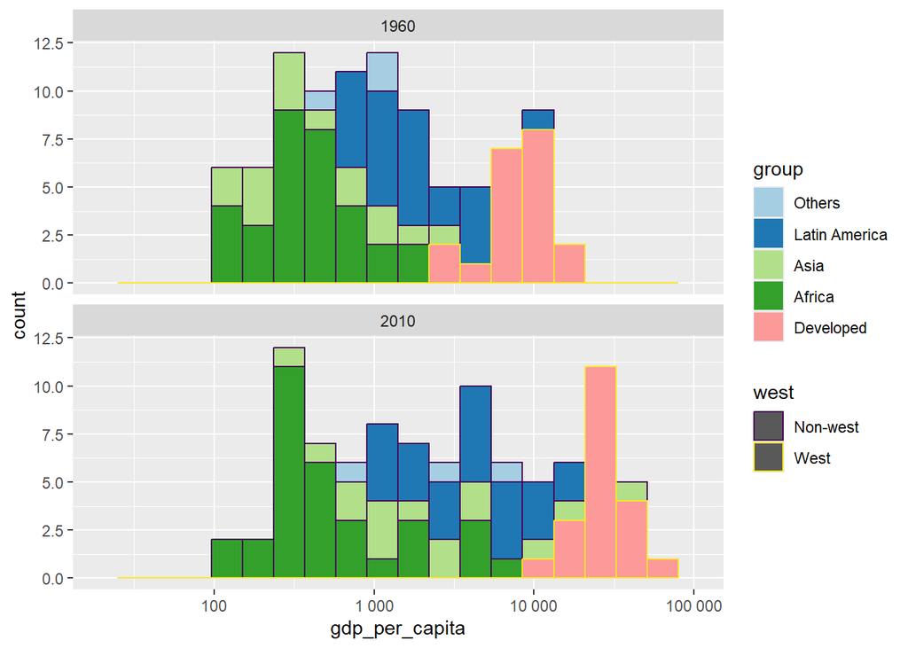

```r
gapminder %>%
  mutate(gdp_per_capita = gdp/population,
         west = ifelse(group == "Developed",
                       "West",
                       "Non-west")) %>%
  filter(year %in% years,
         country %in% country_list) %>%
  group_by(year) %>%
  mutate(weight = population / sum(population) ) %>%
  ungroup() %>%
  ggplot(aes(x = gdp_per_capita,
             #weight = weight,
             fill = group,
             color = west)) +
  geom_histogram(bins = 20, position = "stack") +
  scale_x_continuous(limits = c(20, 100000),
                     trans = "log10",
                     labels = label_number()) +
  scale_fill_brewer(palette = "Paired") +
  scale_color_viridis_d() +
  facet_wrap(~year, ncol=1)
```

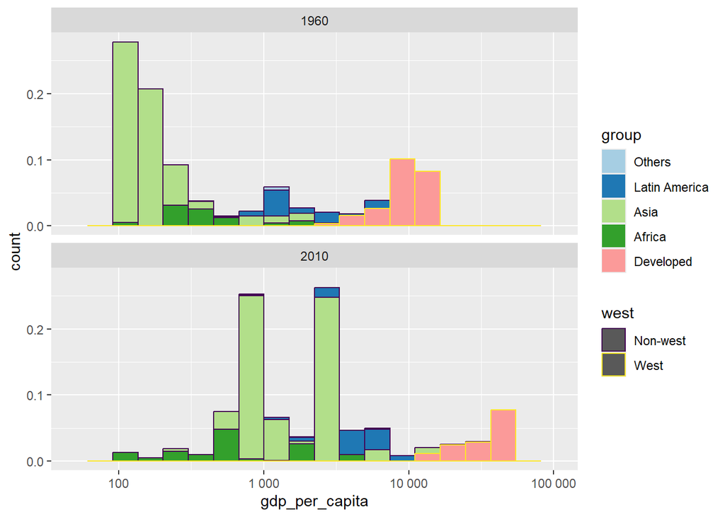

```r
gapminder %>%
  mutate(gdp_per_capita = gdp/population,
         west = ifelse(group == "Developed",
                       "West",
                       "Non-west")) %>%
  filter(year %in% years,
         country %in% country_list) %>%
  group_by(year) %>%
  mutate(weight = population / sum(population) ) %>%
  ungroup() %>%
  ggplot(aes(x = gdp_per_capita,
             weight = weight,
             fill = group,
             color = west)) +
  geom_histogram(bins = 20, position = "stack") +
  scale_x_continuous(limits = c(50, 100000),
                     trans = "log10",
                     labels = label_number()) +
  scale_fill_brewer(palette = "Paired") +
  scale_color_viridis_d() +
  facet_wrap(~year, ncol=1)
```

**What not to do?** Density plot can be confusing sometimes. For example, if we simply stack the density plot to show the distribution of gdp per capita for each group, all groups are equally weighted, which is incorrect.

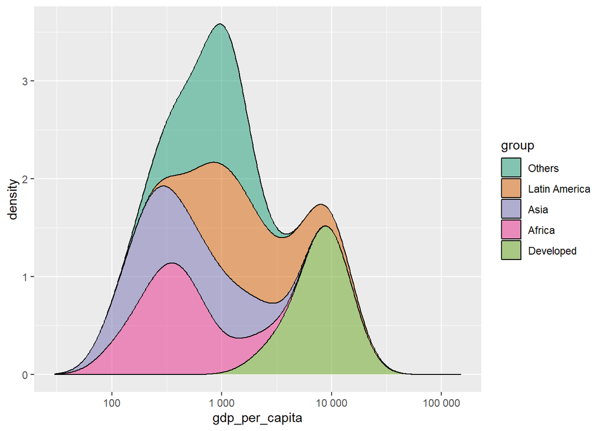

```r
gapminder %>%
  filter(year == past_year & !is.na(gdp_per_capita)) %>%
  ggplot(aes(gdp_per_capita, fill=group)) +
  geom_density(alpha = 0.5,
               position="stack",
               bw = 0.2) +
  scale_x_continuous(trans = "log10", limit = c(30, 150000),
                     labels = label_number()) +
  scale_fill_brewer(palette = "Dark2")
```

We could make area of each density plot proportional to the group size. However, it still misses the population information.

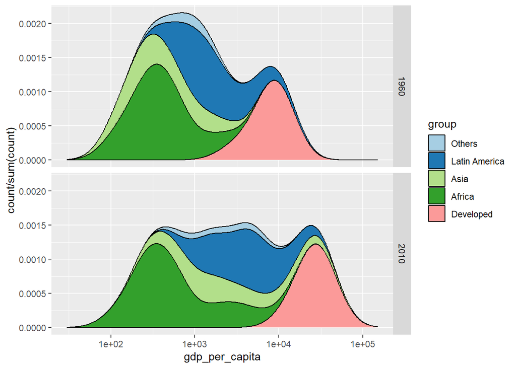

```r
gapminder %>%
  filter(year %in% years & country %in% country_list) %>%
  ggplot(aes(gdp_per_capita, fill = group)) +
    geom_density(aes(y = ..count../sum(..count..)),
                 bw = 0.2, position = "stack") +
    scale_x_continuous(trans = "log10", limit = c(30, 150000)) +
    scale_fill_brewer(palette = "Paired") +
    facet_grid(year ~ .)
```

We could add weight as the population, however, the group size is not properly displayed because `y =` and `weight =` are not compatible in `geom_density` function. In other words, the areas of density plots are proportional to group size, but within each density, the area is proportional to the population.

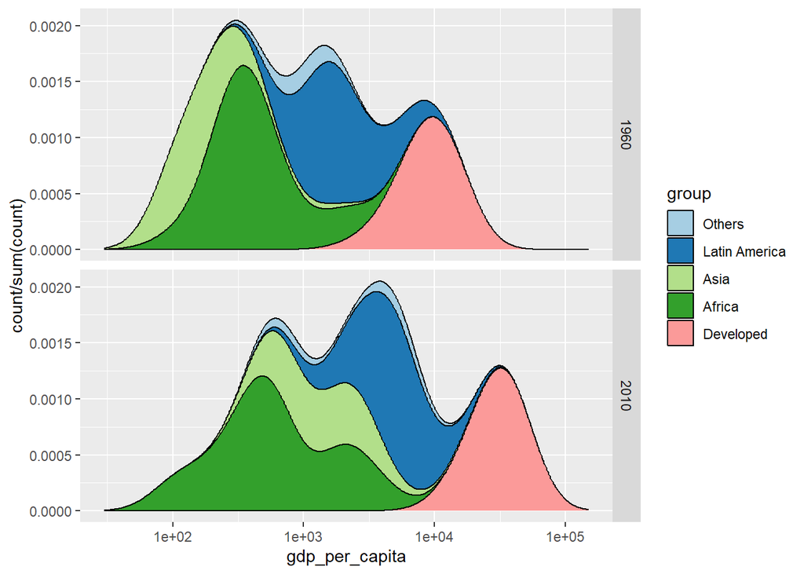

```r
gapminder %>%
  filter(year %in% years & country %in% country_list) %>%
  group_by(year) %>%
  mutate(weight = population / sum(population) ) %>%
  ungroup() %>%
  ggplot(aes(gdp_per_capita, fill = group)) +
    geom_density(aes(y = ..count../sum(..count..),
                     weight = weight),
                 bw = 0.2, position = "stack") +
    scale_x_continuous(trans = "log10", limit = c(30, 150000)) +
    scale_fill_brewer(palette = "Paired") +
    facet_grid(year ~ .)
```

# References

Irizarry, Rafael A. 2019. *Introduction to Data Science: Data Analysis and Prediction Algorithms with r*. 1st ed. Chapman; Hall/CRC. https://rafalab.github.io/dsbook/.

[^1]: https://www.gapminder.org/data/
[^2]: https://en.wikipedia.org/wiki/Hans_Rosling
[^3]: http://www.gapminder.org/
[^4]: https://www.ted.com/talks/hans_rosling_reveals_new_insights_on_poverty?language=en
[^5]: https://www.ted.com/talks/hans_rosling_shows_the_best_stats_you_ve_ever_seen
[^6]: https://www.youtube.com/watch?v=hVimVzgtD6w